# Data Science Capstone: Predict the Next Word

October 17, 2021

## Introduction

The key objective of this project was to create a simple text-prediction application using the R Shiny package. The application that I have built uses the n-gram model to predict the next word in the phrase.

For training the model, I have used the corpus, a collection of written texts from Twitter, News, and Blogs in English.

The size of the data dictionary was optimized by selecting the top combination of bi-, tri-, quad-, quint-, and sext- words.

## Design of the Application

The prediction model uses the principles of **tidy data** to perform text mining in R. The following key steps are involved in building this prediction model.

1. Read the corpus data files, Twitter, blog, and news. This data will be used for training.
2. Clean the raw data and separate it into 2, 3, 4, 5, and 6 words n-grams and save as tibbles
3. Sort the n-grams tibbles by frequency and save the data as *.rds* files
4. N-grams function uses a **back-off** type prediction model. This means, a user supplies an input phrase, and based on the number of words supplied, the model uses the last 5, 4, 3, 2, or 1 word to predict the best 6th, 5th, 4th, 3rd, or 2nd word respectively.
5. Predicted word is displayed to the user

## Introducing: Predict the Next Word App

**Predict the Next Word** app provides a simple user interface to the Prediction algorithm. Using this app is super simple. Just go to the text box and enter your word or phrase, and hit “Nextword”.

Here is a preview of the app:

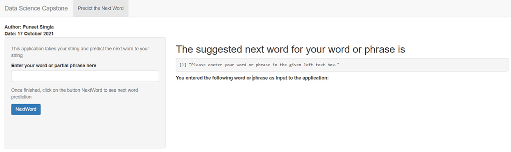

## Reference & Link to the app

[Tidy Data](http://vita.had.co.nz/papers/tidy-data.html)

[Text Mining with R: A Tidy Approach](http://tidytextmining.com/index.html)

[Predict the Next Word App](https://puneetsingla.shinyapps.io/FinalProject/)